# GoFundMe — Status

```r
library(tidyverse)
library(lme4)
library(gridExtra)
library(glue) # for pretty printing
```

## GoFundMe Analysis of Status

```r
projects = read.csv("../../data/processed/gofundme_projects_clean.csv")
projects$month = factor(projects$month)
projects$day_of_week = factor(projects$day_of_week)
projects$status = factor(projects$status)
```

In total, we have N=5223 IID samples to work with.

Removed all random variabes except year because they didn’t help explain any variance in the data beyond what the residuals could capture. Year is a reasonable random effect as well (see Variance Components, Searle et al 2006)

Nesting and Chi2 differences: https://www.psychologie.uzh.ch/dam/jcr:ffffffff-b371-2797-0000-00000fda8f29/chisquare_diff_en.pdf

# Status

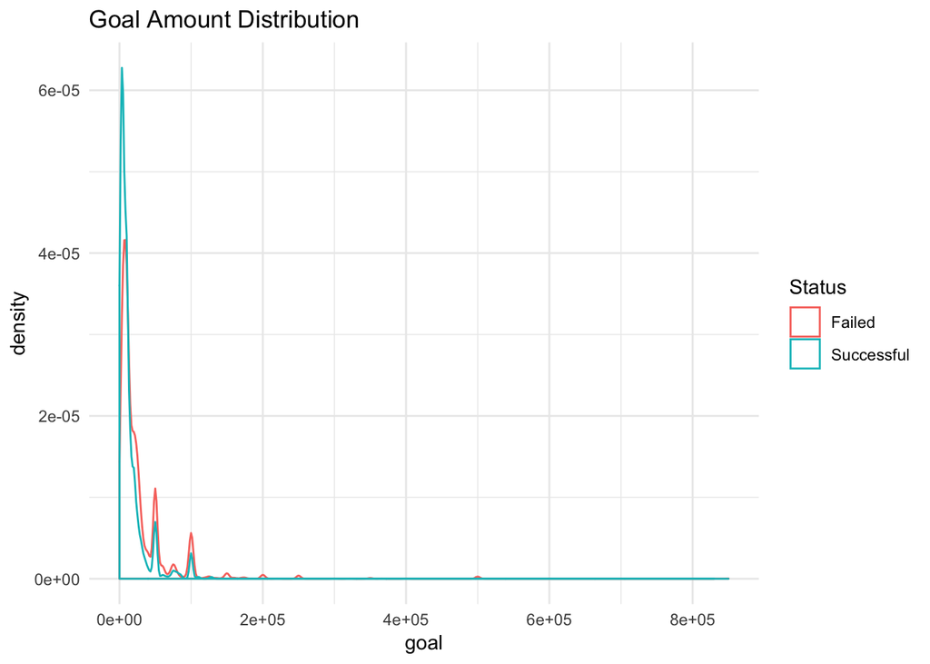

```r
th = theme_minimal()
projects %>%
  ggplot() + th + labs(title="Goal Amount Distribution") + guides(color=guide_legend(title="Status")) +
  geom_density(aes(goal, color=fct_recode(factor(status), "Successful"="1", "Failed"="0")))
```

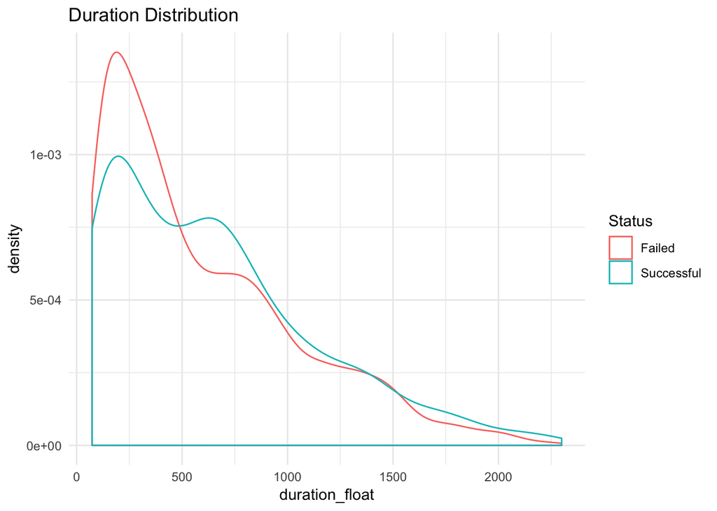

```r
projects %>%
  ggplot() + th + labs(title="Duration Distribution") + guides(color=guide_legend(title="Status")) +
  geom_density(aes(duration_float, color=fct_recode(factor(status), "Successful"="1", "Failed"="0")))
```

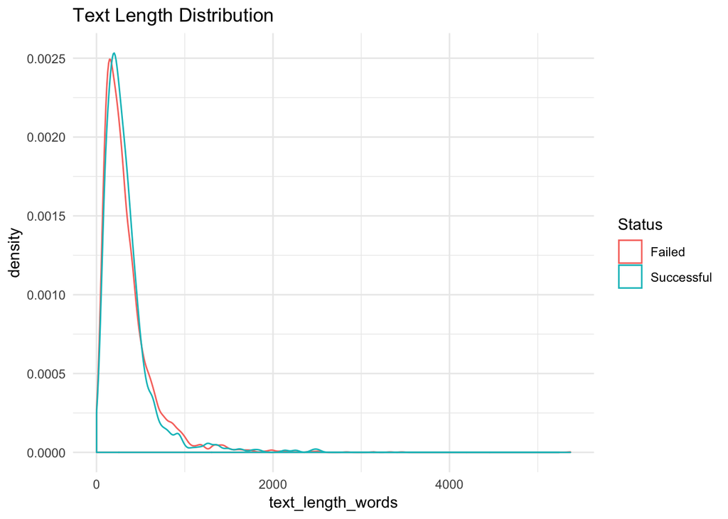

```r
projects %>%
  ggplot() + th + labs(title="Text Length Distribution") + guides(color=guide_legend(title="Status")) +
  geom_density(aes(text_length_words, color=fct_recode(factor(status), "Successful"="1", "Failed"="0")))
```

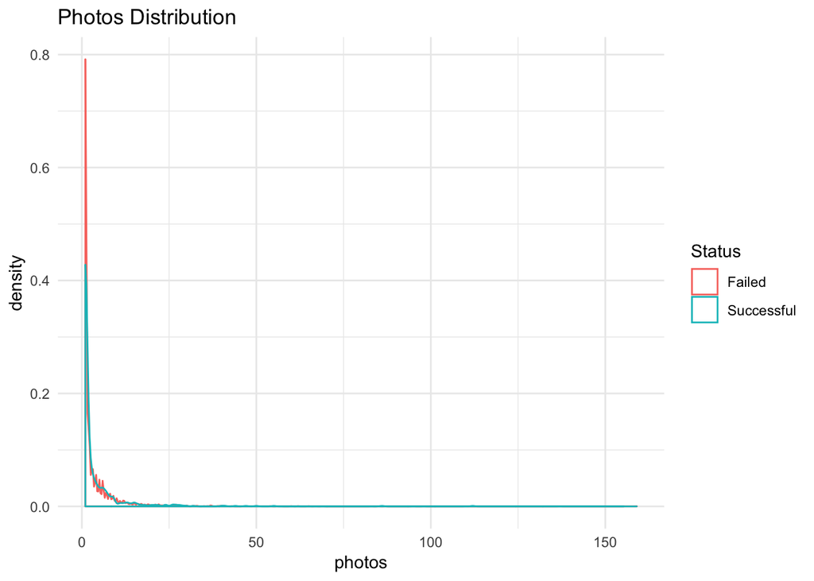

```r
projects %>%
  ggplot() + th + labs(title="Photos Distribution") + guides(color=guide_legend(title="Status")) +
  geom_density(aes(photos, color=fct_recode(factor(status), "Successful"="1", "Failed"="0")))
```

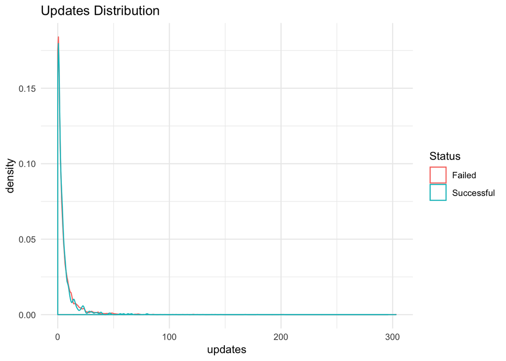

```r
projects %>%
  ggplot() + th + labs(title="Updates Distribution") + guides(color=guide_legend(title="Status")) +
  geom_density(aes(updates, color=fct_recode(factor(status), "Successful"="1", "Failed"="0")))
```

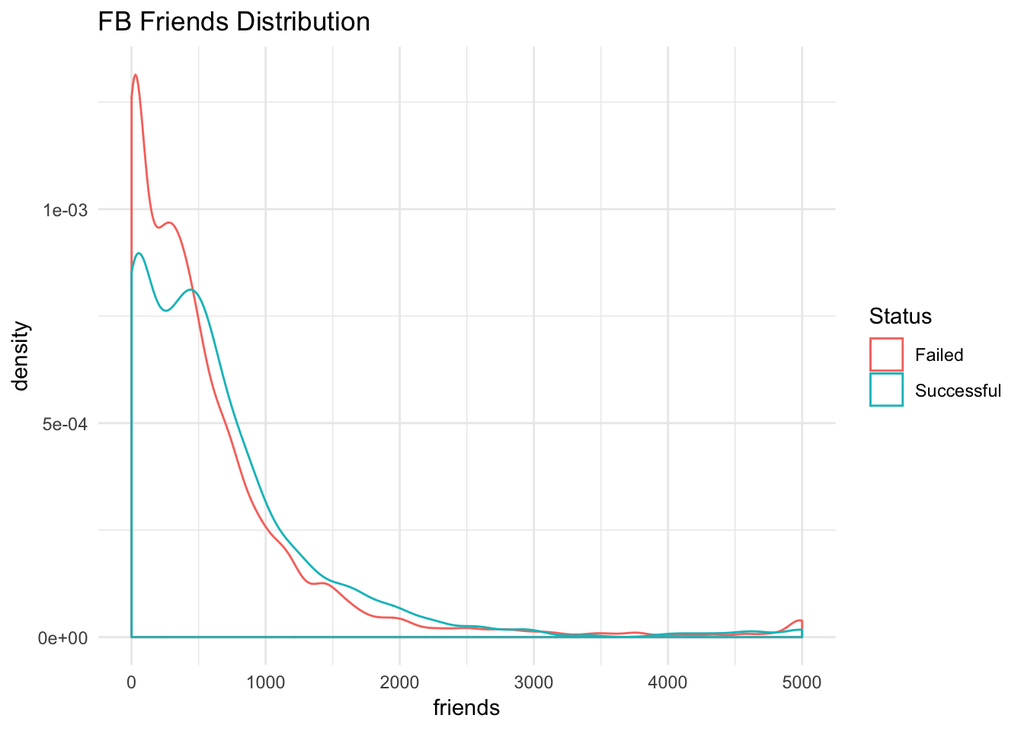

```r
projects %>%
  ggplot() + th + labs(title="FB Friends Distribution") + guides(color=guide_legend(title="Status")) +
  geom_density(aes(friends, color=fct_recode(factor(status), "Successful"="1", "Failed"="0")))
```

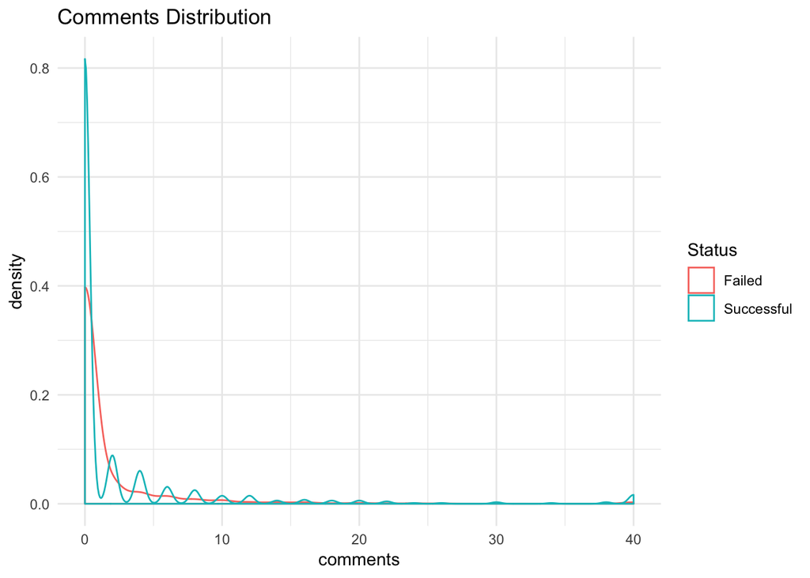

```r
projects %>%
  ggplot() + th + labs(title="Comments Distribution") + guides(color=guide_legend(title="Status")) +
  geom_density(aes(comments, color=fct_recode(factor(status), "Successful"="1", "Failed"="0")))
```

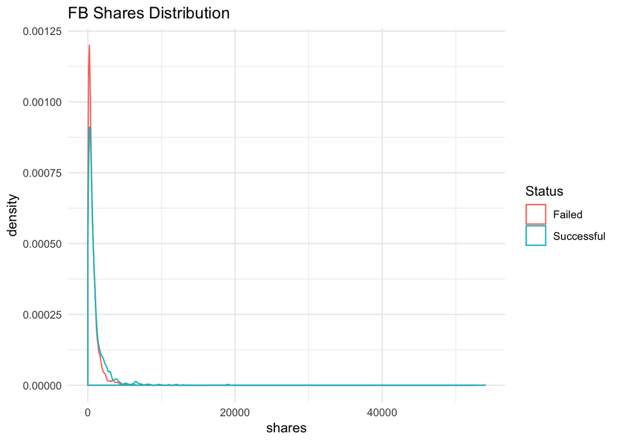

```r
projects %>%
  ggplot() + th + labs(title="FB Shares Distribution") + guides(color=guide_legend(title="Status")) +
  geom_density(aes(shares, color=fct_recode(factor(status), "Successful"="1", "Failed"="0")))
```

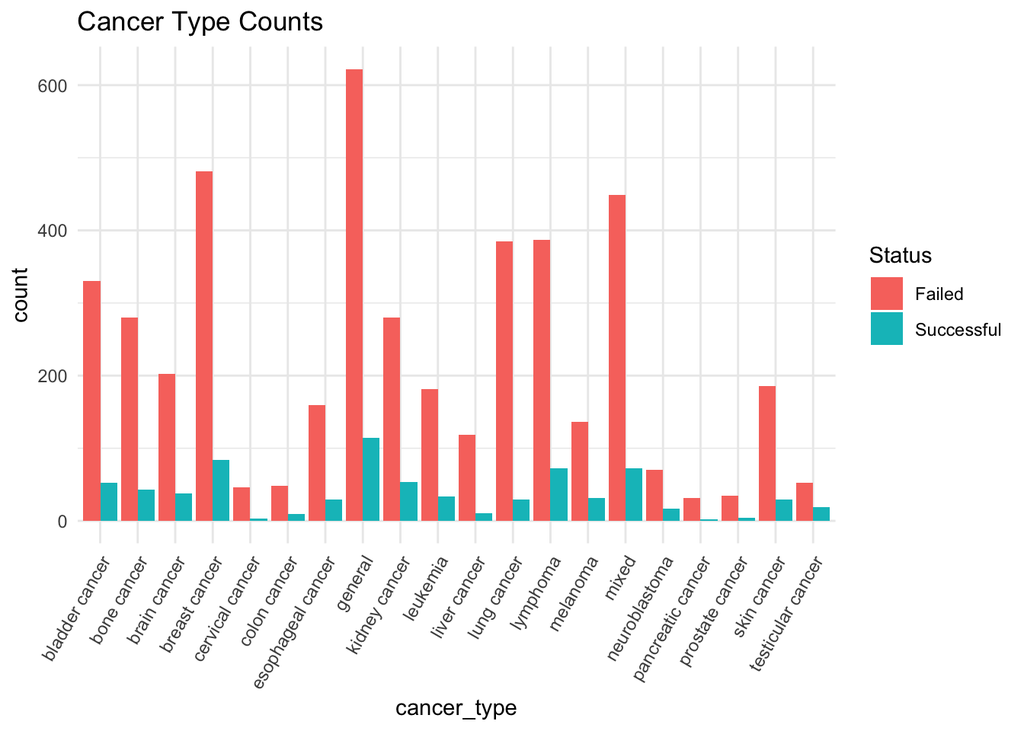

```r
projects %>%
  ggplot() + th + labs(title="Cancer Type Counts") + guides(fill=guide_legend(title="Status")) +
  geom_bar(aes(x=cancer_type, fill=fct_recode(factor(status), "Successful"="1", "Failed"="0")), position="dodge") +
  theme(axis.text.x=element_text(angle = 60, hjust=1))
```

Establish the base formula to build models off of:

```r
base.formula = status ~ shares_sc + friends_sc + updates_sc + photos_sc + goal_sc + text_length_words_sc + duration_float_sc + cancer_type + month + day_of_week + (1|year)
```

Create a helper function to easily compare two models and pretty print the output:

```r
compare = function(model.old, model.new, key, multiplier=1.0) {
  a = anova(model.old, model.new)
  p = a$`Pr(>Chisq)`[2]
  print(glue("Variable: {key}"))
  print(glue("DF diff: {a$`Chi Df`[2]}\t New AIC: {round(a$AIC[2], 1)}\t\t Chisq: {round(a$Chisq[2],1)}\t P(>chisq) = {round(p,4)} {if (p < 0.05) '(significant)' else ''})"))
  effect = as.numeric(summary(mod)$coefficients[key, ])
  print(glue("beta: {round(effect[1],4)} (+/- {round(effect[2],3)})\t stat: {round(effect[3], 2)} => P(>|z|) = {round(effect[4], 4)}"))
  print(glue("odds change: {round((exp(effect[1]*multiplier) - 1)*100, 1)}% ({round((exp((effect[1] - effect[2])*multiplier) - 1)*100, 1)}% to {round((exp((effect[1] + effect[2])*multiplier) - 1)*100, 1)}%)"))
  print(glue(""))
}
```

```r
p = function(var, scl=1, digits=6, mult=1.00, mask=T) {
  mu = mean(projects[mask, var])
  sd = sd(projects[mask, var])
  print(glue("Var: {var}\t Mean: {round(mu,digits)*scl}\t SD: {round(sd,digits)*scl}\t Scale (x{round(mult, 2)}): {paste(round(mult*sd + mu, digits)*scl)}"))
}
p("journey_salience", scl = 1000, digits = 5, mult = 0.6)
```

```
## Var: journey_salience     Mean: 0.52  SD: 1.68    Scale (x0.6): 1.53
```

```r
p("battle_salience", scl = 1000, digits = 5, mult = 0.16)
```

```
## Var: battle_salience  Mean: 3.87  SD: 6.27    Scale (x0.16): 4.87
```

```r
p("journey_prod", digits = 4, mask = projects$journey_metaphor > 0)
```

```
## Var: journey_prod     Mean: 1.5567    SD: 1.0602  Scale (x1): 2.6169
```

```r
p("battle_prod", digits = 4, mask = projects$battle_metaphor > 0)
```

```
## Var: battle_prod  Mean: 3.4581    SD: 3.0339  Scale (x1): 6.492
```

```r
p("first_instantiation", digits = 4, mask = projects$journey_metaphor > 0, mult = 1.6)
```

```
## Var: first_instantiation  Mean: 0.3943    SD: 0.3191  Scale (x1.6): 0.9049
```

```r
p("first_instantiation", digits = 4, mask = projects$battle_metaphor > 0, mult = 1.6)
```

```
## Var: first_instantiation  Mean: 0.3952    SD: 0.3111  Scale (x1.6): 0.8929
```

## Any Metaphor

Examine: does having any instance of metaphor influence status?

Null: having any metaphor is not significantly different from having no metaphor

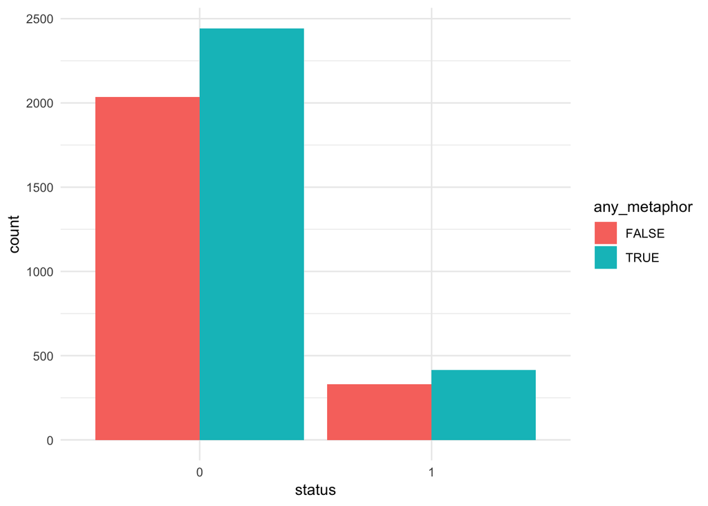

```r
projects %>%
  ggplot() + th + geom_bar(aes(status, fill=any_metaphor), position="dodge")
```

```r
status.mod.base = glmer(base.formula, data = projects, family = "binomial")
# drop1(status.mod.base, test="Chisq")
```

```r
f = update(base.formula,  ~ . - day_of_week)
# drop1(glmer(f, data = projects, family = "binomial"), test="Chisq")
```

```r
f = update(f,  ~ . - month)
# drop1(glmer(f, data = projects, family = "binomial"), test="Chisq")
```

```r
f = update(f,  ~ . - text_length_words_sc)
# drop1(glmer(f, data = projects, family = "binomial"), test="Chisq")
```

```r
f = update(f,  ~ . - friends_sc)
# drop1(glmer(f, data = projects, family = "binomial"), test="Chisq")
```

```r
status.mod = glmer(f, data = projects, family = "binomial")
summary(status.mod)
```

```
## Generalized linear mixed model fit by maximum likelihood (Laplace
##   Approximation) [glmerMod]
##  Family: binomial  ( logit )
## Formula:
## status ~ shares_sc + updates_sc + photos_sc + goal_sc + duration_float_sc +
##     cancer_type + (1 | year)
##    Data: projects
##
##      AIC      BIC   logLik deviance df.resid
##   4012.5   4183.1  -1980.2   3960.5     5197
##
## Scaled residuals:
##     Min      1Q  Median      3Q     Max
## -53.680  -0.454  -0.363  -0.210  17.225
##
## Random effects:
##  Groups Name        Variance Std.Dev.
##  year   (Intercept) 0.02551  0.1597
## Number of obs: 5223, groups:  year, 7
##
## Fixed effects:
##                              Estimate Std. Error z value Pr(>|z|)
## (Intercept)                  -2.15296    0.17550 -12.268  < 2e-16 ***
## shares_sc                     0.45709    0.05899   7.749 9.26e-15 ***
## updates_sc                   -0.38865    0.07506  -5.178 2.24e-07 ***
## photos_sc                     0.18120    0.04790   3.783 0.000155 ***
## goal_sc                      -1.37697    0.12696 -10.845  < 2e-16 ***
## duration_float_sc             0.15478    0.06288   2.462 0.013835 *
## cancer_typebone cancer        0.01509    0.22978   0.066 0.947626
## cancer_typebrain cancer       0.32190    0.23915   1.346 0.178303
## cancer_typebreast cancer      0.15898    0.19553   0.813 0.416170
## cancer_typecervical cancer   -0.94589    0.61871  -1.529 0.126310
## cancer_typecolon cancer       0.25363    0.41480   0.611 0.540895
## cancer_typeesophageal cancer  0.24387    0.25666   0.950 0.342021
## cancer_typegeneral            0.27955    0.18826   1.485 0.137566
## cancer_typekidney cancer      0.26660    0.21653   1.231 0.218252
## cancer_typeleukemia           0.29243    0.24982   1.171 0.241768
## cancer_typeliver cancer      -0.63373    0.37861  -1.674 0.094164 .
## cancer_typelung cancer       -0.68674    0.24722  -2.778 0.005472 **
## cancer_typelymphoma           0.19588    0.20173   0.971 0.331544
## cancer_typemelanoma           0.30795    0.25458   1.210 0.226410
## cancer_typemixed              0.07049    0.20084   0.351 0.725594
## cancer_typeneuroblastoma      0.72325    0.32728   2.210 0.027115 *
## cancer_typepancreatic cancer -0.49940    0.76381  -0.654 0.513218
## cancer_typeprostate cancer   -0.02413    0.56221  -0.043 0.965759
## cancer_typeskin cancer       -0.02950    0.25329  -0.116 0.907276
## cancer_typetesticular cancer  0.81723    0.31680   2.580 0.009891 **
## ---
## Signif. codes:  0 '***' 0.001 '**' 0.01 '*' 0.05 '.' 0.1 ' ' 1
```

```
##
## Correlation matrix not shown by default, as p = 25 > 12.
## Use print(x, correlation=TRUE)  or
##     vcov(x)        if you need it
```

### Results

```r
mod = glmer(update(f,  ~ . + any_metaphor), data = projects, family = "binomial")
compare(status.mod, mod, "any_metaphorTRUE")
```

```
## Variable: any_metaphorTRUE
## DF diff: 1    New AIC: 4012.5         Chisq: 2    P(>chisq) = 0.1545 )
## beta: 0.1192 (+/- 0.084)  stat: 1.42 => P(>|z|) = 0.1548
## odds change: 12.7% (3.6% to 22.5%)
```

```r
mod = glmer(update(base.formula,  ~ . + any_metaphor), data = projects, family = "binomial")
compare(status.mod, mod, "any_metaphorTRUE")
```

```
## Variable: any_metaphorTRUE
## DF diff: 20   New AIC: 4037.9         Chisq: 14.6     P(>chisq) = 0.8 )
## beta: 0.1142 (+/- 0.086)  stat: 1.33 => P(>|z|) = 0.1824
## odds change: 12.1% (2.9% to 22.1%)
```

## Both Metaphors

Examine: does having both metaphor families present influence status?

Null: having both metaphor families is not significantly different from having no metaphor

```r
projects.both = projects[(1-projects$any_metaphor) | projects$both_metaphor, ] # only projects with both or none
```

N = 2802

Perform model selection to prevent overfitting:

```r
status.mod.base = glmer(base.formula, data = projects.both, family = "binomial")
# drop1(status.mod.base, test="Chisq")
```

```r
f = update(base.formula,  ~ . - month)
# drop1(glmer(f, data = projects.both, family = "binomial"), test="Chisq")
```

```r
f = update(f,  ~ . - day_of_week)
# drop1(glmer(f, data = projects.both, family = "binomial"), test="Chisq")
```

```r
f = update(f,  ~ . - text_length_words_sc)
# drop1(glmer(f, data = projects.both, family = "binomial"), test="Chisq")
```

```r
f = update(f,  ~ . - friends_sc)
# drop1(glmer(f, data = projects.both, family = "binomial"), test="Chisq")
```

```r
f = update(f,  ~ . - duration_float_sc)
# drop1(glmer(f, data = projects.both, family = "binomial"), test="Chisq")
```

```r
status.mod = glmer(f, data = projects.both, family = "binomial")
# summary(status.mod)
```

### Results

```r
mod = glmer(update(f,  ~ . + both_metaphor), data = projects.both, family = "binomial")
compare(status.mod, mod, "both_metaphorTRUE")
```

```
## Variable: both_metaphorTRUE
## DF diff: 1    New AIC: 2154.7         Chisq: 2.2  P(>chisq) = 0.1409 )
## beta: 0.2318 (+/- 0.155)  stat: 1.49 => P(>|z|) = 0.1353
## odds change: 26.1% (8% to 47.3%)
```

```r
mod = glmer(update(base.formula,  ~ . + both_metaphor), data = projects.both, family = "binomial")
compare(status.mod.base, mod, "both_metaphorTRUE")
```

```
## Variable: both_metaphorTRUE
## DF diff: 1    New AIC: 2177.4         Chisq: 1.5  P(>chisq) = 0.228 )
```

```
## beta: 0.2021 (+/- 0.166)  stat: 1.22 => P(>|z|) = 0.2233
## odds change: 22.4% (3.7% to 44.5%)
```

## Some Metaphor

Examine: does having only journey/battle, or dominant journey/battle, influence status?

Null: having only journey/battle, or dominant journey/battle, is not significantly different from negative

```r
projects.some = projects[projects$any_metaphor, ]
```

N = 2858

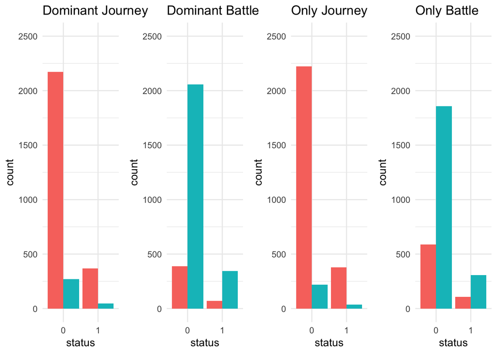

```r
p1 = projects.some %>%
  ggplot() + th +
  geom_bar(aes(status, fill=dom_journey), position = "dodge") +
  lims(y=c(0,2500)) + labs(title="Dominant Journey") + theme(legend.position = "none")

p2 = projects.some %>%
  ggplot() + th +
  geom_bar(aes(status, fill=dom_battle), position = "dodge") +
  lims(y=c(0,2500)) + labs(title="Dominant Battle") + theme(legend.position = "none")

p3 = projects.some %>%
  ggplot() + th +
  geom_bar(aes(status, fill=only_journey), position = "dodge") +
  lims(y=c(0,2500)) + labs(title="Only Journey") + theme(legend.position = "none")

p4 = projects.some %>%
  ggplot() + th +
  geom_bar(aes(status, fill=only_battle), position = "dodge") +
  lims(y=c(0,2500)) + labs(title="Only Battle") + theme(legend.position = "none")

grid.arrange(p1, p2, p3, p4, nrow=1)
```

Perform model selection to prevent overfitting:

```r
status.mod.base = glmer(base.formula, data = projects.some, family = "binomial")
# drop1(status.mod.base, test="Chisq")
```

```r
f = update(base.formula,  ~ . - text_length_words_sc)
# drop1(glmer(f, data = projects.some, family = "binomial"), test="Chisq")
```

```r
f = update(f,  ~ . - friends_sc)
# drop1(glmer(f, data = projects.some, family = "binomial"), test="Chisq")
```

```r
f = update(f,  ~ . - month)
# drop1(glmer(f, data = projects.some, family = "binomial"), test="Chisq")
```

```r
f = update(f,  ~ . - day_of_week)
# drop1(glmer(f, data = projects.some, family = "binomial"), test="Chisq")
```

```r
f = update(f,  ~ . - duration_float_sc)
# drop1(glmer(f, data = projects.some, family = "binomial"), test="Chisq")
```

```r
status.mod = glmer(f, data = projects.some, family = "binomial")
# summary(status.mod)
```

### Results

```r
mod = glmer(update(f,  ~ . + dom_journey), data = projects.some, family = "binomial")
compare(status.mod, mod, "dom_journeyTRUE")
```

```
## Variable: dom_journeyTRUE
## DF diff: 1    New AIC: 2241.9         Chisq: 0    P(>chisq) = 0.8834 )
## beta: 0.0257 (+/- 0.175)  stat: 0.15 => P(>|z|) = 0.883
## odds change: 2.6% (-13.8% to 22.2%)
```

```r
mod = glmer(update(f,  ~ . + dom_battle), data = projects.some, family = "binomial")
compare(status.mod, mod, "dom_battleTRUE")
```

```
## Variable: dom_battleTRUE
## DF diff: 1    New AIC: 2241.9         Chisq: 0    P(>chisq) = 0.8589 )
## beta: -0.0265 (+/- 0.149)     stat: -0.18 => P(>|z|) = 0.8587
## odds change: -2.6% (-16.1% to 13%)
```

```r
mod = glmer(update(f,  ~ . + only_journey), data = projects.some, family = "binomial")
compare(status.mod, mod, "only_journeyTRUE")
```

```
## Variable: only_journeyTRUE
## DF diff: 1    New AIC: 2241.9         Chisq: 0    P(>chisq) = 0.9028 )
## beta: -0.0233 (+/- 0.192)     stat: -0.12 => P(>|z|) = 0.903
## odds change: -2.3% (-19.3% to 18.3%)
```

```r
mod = glmer(update(f,  ~ . + only_battle), data = projects.some, family = "binomial")
compare(status.mod, mod, "only_battleTRUE")
```

```
## Variable: only_battleTRUE
## DF diff: 1    New AIC: 2241       Chisq: 0.9  P(>chisq) = 0.3458 )
## beta: -0.1208 (+/- 0.127)     stat: -0.95 => P(>|z|) = 0.3427
## odds change: -11.4% (-22% to 0.7%)
```

```r
mod = glmer(update(base.formula,  ~ . + dom_journey), data = projects.some, family = "binomial")
compare(status.mod.base, mod, "dom_journeyTRUE")
```

```
## Variable: dom_journeyTRUE
## DF diff: 1    New AIC: 2259.8         Chisq: 0    P(>chisq) = 0.8784 )
## beta: 0.0271 (+/- 0.177)  stat: 0.15 => P(>|z|) = 0.8783
## odds change: 2.7% (-13.9% to 22.6%)
```

```r
mod = glmer(update(base.formula,  ~ . + dom_battle), data = projects.some, family = "binomial")
compare(status.mod.base, mod, "dom_battleTRUE")
```

```
## Variable: dom_battleTRUE
## DF diff: 1    New AIC: 2259.8         Chisq: 0    P(>chisq) = 0.9066 )
## beta: -0.0177 (+/- 0.151)     stat: -0.12 => P(>|z|) = 0.9067
## odds change: -1.8% (-15.5% to 14.2%)
```

```r
mod = glmer(update(base.formula,  ~ . + only_journey), data = projects.some, family = "binomial")
compare(status.mod.base, mod, "only_journeyTRUE")
```

```
## Variable: only_journeyTRUE
## DF diff: 1    New AIC: 2259.8         Chisq: 0    P(>chisq) = 0.9152 )
## beta: -0.0206 (+/- 0.193)     stat: -0.11 => P(>|z|) = 0.9153
## odds change: -2% (-19.3% to 18.9%)
```

```r
mod = glmer(update(base.formula,  ~ . + only_battle), data = projects.some, family = "binomial")
compare(status.mod.base, mod, "only_battleTRUE")
```

```
## Variable: only_battleTRUE
## DF diff: 1    New AIC: 2259.3         Chisq: 0.5  P(>chisq) = 0.4588 )
## beta: -0.0972 (+/- 0.131)     stat: -0.74 => P(>|z|) = 0.4568
## odds change: -9.3% (-20.4% to 3.4%)
```

## Journey

```r
projects.jor = projects[projects$journey_metaphor > 0, ]
```

N = 695

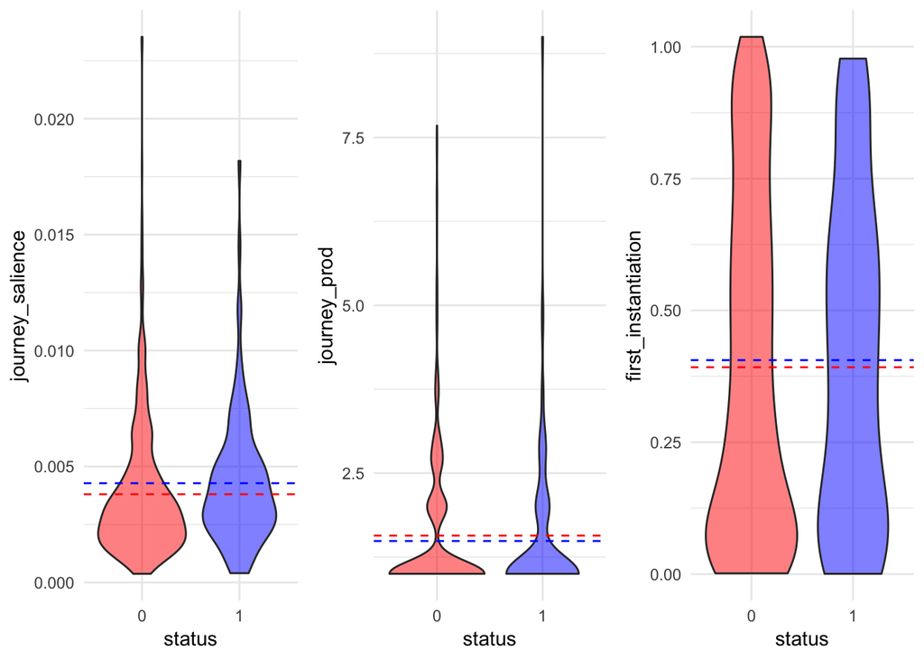

```r
p1 = projects.jor %>%
  ggplot() + th +
  geom_violin(aes(status, journey_salience, fill=status)) +
  scale_fill_manual(values = c("0" = alpha("red", 0.5), "1" = alpha("blue", 0.5)), guide=F) +
  geom_hline(yintercept = mean(projects.jor[projects.jor$status == 0, ]$journey_salience), lty=2, color="red") +
  geom_hline(yintercept = mean(projects.jor[projects.jor$status == 1, ]$journey_salience), lty=2, color="blue")

p2 = projects.jor %>%
  ggplot() + th +
  geom_violin(aes(status, journey_prod, fill=status)) +
  scale_fill_manual(values = c("0" = alpha("red", 0.5), "1" = alpha("blue", 0.5)), guide=F) +
  geom_hline(yintercept = mean(projects.jor[projects.jor$status == 0, ]$journey_prod), lty=2, color="red") +
  geom_hline(yintercept = mean(projects.jor[projects.jor$status == 1, ]$journey_prod), lty=2, color="blue")

p3 = projects.jor %>%
  ggplot() + th +
  geom_violin(aes(status, first_instantiation, fill=status)) +
  scale_fill_manual(values = c("0" = alpha("red", 0.5), "1" = alpha("blue", 0.5)), guide=F) +
  geom_hline(yintercept = mean(projects.jor[projects.jor$status == 0, ]$first_instantiation), lty=2, color="red") +
  geom_hline(yintercept = mean(projects.jor[projects.jor$status == 1, ]$first_instantiation), lty=2, color="blue")

grid.arrange(p1, p2, p3, nrow=1)
```

Perform model selection to prevent overfitting:

```r
status.mod.base = glmer(base.formula, data = projects.jor, family = "binomial")
```

```
## singular fit
```

```r
# drop1(status.mod.base, test="Chisq")
```

```r
f = update(base.formula,  ~ . - friends_sc)
# drop1(glmer(f, data = projects.jor, family = "binomial"), test="Chisq")
```

```r
f = update(f,  ~ . - day_of_week)
# drop1(glmer(f, data = projects.jor, family = "binomial"), test="Chisq")
```

```r
f = update(f,  ~ . - text_length_words_sc)
# drop1(glmer(f, data = projects.jor, family = "binomial"), test="Chisq")
```

```r
f = update(f,  ~ . - cancer_type)
# drop1(glmer(f, data = projects.jor, family = "binomial"), test="Chisq")
```

```r
f = update(f,  ~ . - duration_float_sc)
# drop1(glmer(f, data = projects.jor, family = "binomial"), test="Chisq")
```

```r
f = update(f,  ~ . - month)
# drop1(glmer(f, data = projects.jor, family = "binomial"), test="Chisq")
```

```r
status.mod = glmer(f, data = projects.jor, family = "binomial")
```

```
## singular fit
```

```r
# summary(status.mod)
```

### Results

```r
mod = glmer(update(f,  ~ . + scale(journey_salience)), data = projects.jor, family = "binomial")
```

```
## singular fit
```

```r
compare(status.mod, mod, "scale(journey_salience)", 0.6)
```

```
## Variable: scale(journey_salience)
## DF diff: 1    New AIC: 570        Chisq: 1.3  P(>chisq) = 0.2475 )
## beta: 0.1173 (+/- 0.099)  stat: 1.18 => P(>|z|) = 0.2365
## odds change: 7.3% (1.1% to 13.9%)
```

```r
mod = glmer(update(f,  ~ . + scale(journey_prod)), data = projects.jor, family = "binomial")
```

```
## singular fit
```

```r
compare(status.mod, mod, "scale(journey_prod)")
```

```
## Variable: scale(journey_prod)
## DF diff: 1    New AIC: 571.3      Chisq: 0    P(>chisq) = 0.8685 )
## beta: -0.0195 (+/- 0.119)     stat: -0.16 => P(>|z|) = 0.8693
## odds change: -1.9% (-12.9% to 10.4%)
```

```r
mod = glmer(update(f,  ~ . + scale(first_instantiation)), data = projects.jor, family = "binomial")
```

```
## singular fit
```

```r
compare(status.mod, mod, "scale(first_instantiation)")
```

```
## Variable: scale(first_instantiation)
## DF diff: 1    New AIC: 571.2      Chisq: 0.1  P(>chisq) = 0.7748 )
## beta: 0.0309 (+/- 0.108)  stat: 0.29 => P(>|z|) = 0.7745
## odds change: 3.1% (-7.4% to 14.9%)
```

```r
mod = glmer(update(base.formula,  ~ . + scale(journey_salience)), data = projects.jor, family = "binomial")
```

```
## singular fit
```

```r
compare(status.mod.base, mod, "scale(journey_salience)", 0.6)
```

```
## Variable: scale(journey_salience)
## DF diff: 1    New AIC: 611.7      Chisq: 0.1  P(>chisq) = 0.7335 )
## beta: 0.0425 (+/- 0.124)  stat: 0.34 => P(>|z|) = 0.7316
## odds change: 2.6% (-4.8% to 10.5%)
```

```r
mod = glmer(update(base.formula,  ~ . + scale(journey_prod)), data = projects.jor, family = "binomial")
```

```
## singular fit
```

```r
compare(status.mod.base, mod, "scale(journey_prod)")
```

```
## Variable: scale(journey_prod)
## DF diff: 1    New AIC: 611.8      Chisq: 0.1  P(>chisq) = 0.7966 )
## beta: 0.0347 (+/- 0.134)  stat: 0.26 => P(>|z|) = 0.7953
## odds change: 3.5% (-9.4% to 18.3%)
```

```r
mod = glmer(update(base.formula,  ~ . + scale(first_instantiation)), data = projects.jor, family = "binomial")
```

```
## singular fit
```

```r
compare(status.mod.base, mod, "scale(first_instantiation)")
```

```
## Variable: scale(first_instantiation)
## DF diff: 1    New AIC: 611.8      Chisq: 0    P(>chisq) = 0.9267 )
```

```
## beta: -0.0108 (+/- 0.118)     stat: -0.09 => P(>|z|) = 0.9267
## odds change: -1.1% (-12.1% to 11.3%)
```

## Battle

```r
projects.bat = projects[projects$battle_metaphor > 0, ]
```

N = 2600

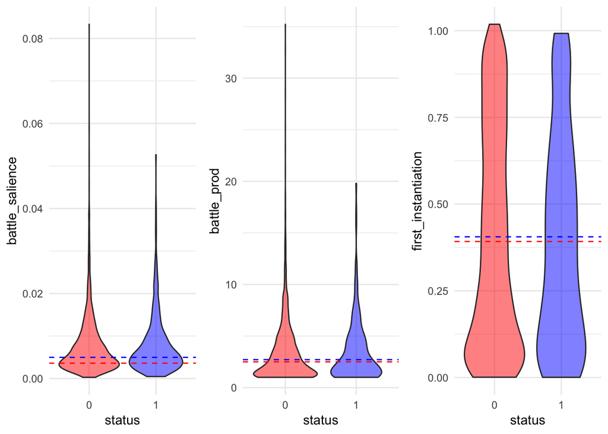

```r
p1 = projects.bat %>%
  ggplot() + th +
  geom_violin(aes(status, battle_salience, fill=status)) +
  scale_fill_manual(values = c("0" = alpha("red", 0.5), "1" = alpha("blue", 0.5)), guide=F) +
  geom_hline(yintercept = mean(projects.jor[projects.jor$status == 0, ]$battle_salience), lty=2, color="red") +
  geom_hline(yintercept = mean(projects.jor[projects.jor$status == 1, ]$battle_salience), lty=2, color="blue")

p2 = projects.bat %>%
  ggplot() + th +
  geom_violin(aes(status, battle_prod, fill=status)) +
  scale_fill_manual(values = c("0" = alpha("red", 0.5), "1" = alpha("blue", 0.5)), guide=F) +
  geom_hline(yintercept = mean(projects.jor[projects.jor$status == 0, ]$battle_prod), lty=2, color="red") +
  geom_hline(yintercept = mean(projects.jor[projects.jor$status == 1, ]$battle_prod), lty=2, color="blue")

p3 = projects.bat %>%
  ggplot() + th +
  geom_violin(aes(status, first_instantiation, fill=status)) +
  scale_fill_manual(values = c("0" = alpha("red", 0.5), "1" = alpha("blue", 0.5)), guide=F) +
  geom_hline(yintercept = mean(projects.jor[projects.jor$status == 0, ]$first_instantiation), lty=2, color="red") +
  geom_hline(yintercept = mean(projects.jor[projects.jor$status == 1, ]$first_instantiation), lty=2, color="blue")

grid.arrange(p1, p2, p3, nrow=1)
```

Perform model selection to prevent overfitting:

```r
status.mod.base = glmer(base.formula, data = projects.bat, family = "binomial")
# drop1(status.mod.base, test="Chisq")
```

```r
f = update(base.formula,  ~ . - friends_sc)
# drop1(glmer(f, data = projects.bat, family = "binomial"), test="Chisq")
```

```r
f = update(f,  ~ . - text_length_words_sc)
# drop1(glmer(f, data = projects.bat, family = "binomial"), test="Chisq")
```

```r
f = update(f,  ~ . - day_of_week)
# drop1(glmer(f, data = projects.bat, family = "binomial"), test="Chisq")
```

```r
f = update(f,  ~ . - month)
# drop1(glmer(f, data = projects.bat, family = "binomial"), test="Chisq")
```

```r
f = update(f,  ~ . - photos_sc)
# drop1(glmer(f, data = projects.bat, family = "binomial"), test="Chisq")
```

```r
f = update(f,  ~ . - duration_float_sc)
# drop1(glmer(f, data = projects.bat, family = "binomial"), test="Chisq")
```

```r
status.mod = glmer(f, data = projects.bat, family = "binomial")
# summary(status.mod)
```

### Results

```r
mod = glmer(update(f,  ~ . + scale(battle_salience)), data = projects.bat, family = "binomial")
compare(status.mod, mod, "scale(battle_salience)", 0.16)
```

```
## Variable: scale(battle_salience)
## DF diff: 1    New AIC: 2044.4         Chisq: 0    P(>chisq) = 0.8571 )
## beta: 0.0103 (+/- 0.057)  stat: 0.18 => P(>|z|) = 0.8566
## odds change: 0.2% (-0.7% to 1.1%)
```

```r
mod = glmer(update(f,  ~ . + scale(battle_prod)), data = projects.bat, family = "binomial")
compare(status.mod, mod, "scale(battle_prod)")
```

```
## Variable: scale(battle_prod)
## DF diff: 1    New AIC: 2042.1         Chisq: 2.3  P(>chisq) = 0.132 )
## beta: 0.0859 (+/- 0.056)  stat: 1.54 => P(>|z|) = 0.1234
## odds change: 9% (3.1% to 15.2%)
```

```r
mod = glmer(update(f,  ~ . + scale(first_instantiation)), data = projects.bat, family = "binomial")
compare(status.mod, mod, "scale(first_instantiation)")
```

```
## Variable: scale(first_instantiation)
## DF diff: 1    New AIC: 2042.9         Chisq: 1.5  P(>chisq) = 0.2169 )
## beta: -0.0727 (+/- 0.059)     stat: -1.23 => P(>|z|) = 0.2183
## odds change: -7% (-12.3% to -1.4%)
```

```r
mod = glmer(update(base.formula,  ~ . + scale(battle_salience)), data = projects.bat, family = "binomial")
compare(status.mod.base, mod, "scale(battle_salience)", 0.16)
```

```
## Variable: scale(battle_salience)
## DF diff: 1    New AIC: 2061.9         Chisq: 0.2  P(>chisq) = 0.6286 )
## beta: 0.0302 (+/- 0.062)  stat: 0.49 => P(>|z|) = 0.6261
## odds change: 0.5% (-0.5% to 1.5%)
```

```r
mod = glmer(update(base.formula,  ~ . + scale(battle_prod)), data = projects.bat, family = "binomial")
compare(status.mod.base, mod, "scale(battle_prod)")
```

```
## Variable: scale(battle_prod)
## DF diff: 1    New AIC: 2060.5         Chisq: 1.6  P(>chisq) = 0.1994 )
## beta: 0.0764 (+/- 0.059)  stat: 1.3 => P(>|z|) = 0.1925
## odds change: 7.9% (1.8% to 14.5%)
```

```r
mod = glmer(update(base.formula,  ~ . + scale(first_instantiation)), data = projects.bat, family = "binomial")
compare(status.mod.base, mod, "scale(first_instantiation)")
```

```
## Variable: scale(first_instantiation)
## DF diff: 1    New AIC: 2061       Chisq: 1.1  P(>chisq) = 0.2866 )
## beta: -0.0637 (+/- 0.06)  stat: -1.06 => P(>|z|) = 0.2878
## odds change: -6.2% (-11.6% to -0.4%)
```